# Pre-soothing species trends - priority

Nick Isaac

2024-02-28

In this document we smooth the species trends for the England priority species abundance index. The input data is the complete set of index values (one per species per year) that has been prepared in early 2026. For most species the species abundance time-series run to 2024.

In that dataset, trends for all species are unsmoothed, with the exception of the bats. However, for several datasets there are both smoothed and unsmoothed variants.

# Load and prepare data

Load the raw data and examine.

```r
nrow(data <- read.csv(file.path(datadir, "d6_spp_timeseries_engto24_120326.csv")))
```

```
## [1] 7318
```

```r
# check for NAs
table(is.na(data$index))
```

```
##
## FALSE  TRUE
##  7139   179
```

```r
#remove the NAs
nrow(data <- subset(data, !is.na(index)))
```

```
## [1] 7139
```

```r
# check number of species
length(unique(data$species))
```

```
## [1] 161
```

Let’s remind ourselves of the taxonomic coverage

```r
oneRowPerSpecies <- unique(data[,c("species","group","survey")])
table(oneRowPerSpecies$group)
```

```
##
##            birds       bumblebees      butterflies             fish
##               44                1               21                8
## fw invertebrates          mammals            moths  vascular plants
##                2                8               76                1
```

```r
table(oneRowPerSpecies$survey)
```

```
##
##    bbs_m beewalks     fish   fw_inv     nbmp     ndmp     npms    nwvmp
##        1        1        8        2        5        1        1        1
##  prior_m     rbbp      ris     scar    ukbms       up      wbi     wwbi
##       10        6       66        2       21        3       29        4
```

Let’s look at which datasets come already pre-smoothed

```r
(smoothedAlready <- table(data$survey, !is.na(data$index_sm)))
```

```
##
##            FALSE TRUE
##   bbs_m        0   25
##   beewalks    15    0
##   fish       169    0
##   fw_inv      24    0
##   nbmp         0  135
##   ndmp         0   27
##   npms        10    0
##   nwvmp        0   10
##   prior_m    190    0
##   rbbp       273    0
##   ris       3628    0
##   scar        10    0
##   ukbms      949    0
##   up           0   81
##   wbi          0 1401
##   wwbi         0  192
```

we need a list of those species that are already smoothed

```r
SmoothedAlreadySp <- unique(subset(data, !is.na(data$index_sm))$species)
```

BBS, BBS_m, NDMP (Dormouse), Wild Bird Indicators and WWBI all have an index_sm value. Let’s plot them

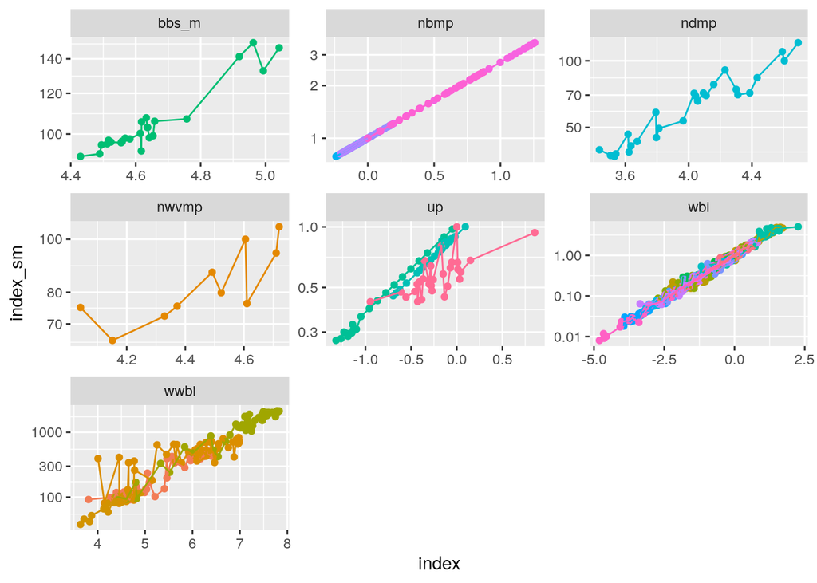

```r
ggplot(data=subset(data, species %in% SmoothedAlreadySp), aes(x=index, y=index_sm, col=species)) +
  geom_point() + geom_line() +
  scale_y_log10() +
  theme(legend.position = "none") +
  facet_wrap(~survey, scales="free")
```

So, for species in these groups

```r
smoothedAlready[,2] > 0
```

```
##    bbs_m beewalks     fish   fw_inv     nbmp     ndmp     npms    nwvmp
##     TRUE    FALSE    FALSE    FALSE     TRUE     TRUE    FALSE     TRUE
##  prior_m     rbbp      ris     scar    ukbms       up      wbi     wwbi
##    FALSE    FALSE    FALSE    FALSE    FALSE     TRUE     TRUE     TRUE
```

We know that bats have also been smoothed. But in this case, only the smoothed index has been provided (whereas for others we’ve used the unsmoothed index but kept a copy of the smoothed index.

```r
as.data.frame(data %>%
                group_by(survey) %>%
                summarise(n=length(index),
                          min=round(min(index, na.rm=T),1),
                          median= round(median(index, na.rm=T),1),
                          max=round(max(index, na.rm=T),1)
))
```

| survey | n | min | median | max |
| --- | --- | --- | --- | --- |
| bbs_m | 25 | 4.4 | 4.6 | 5.0 |
| beewalks | 15 | -2.2 | -0.8 | -0.1 |
| fish | 169 | -14.4 | -7.0 | -3.0 |
| fw_inv | 24 | -6.2 | -5.0 | -3.5 |
| nbmp | 135 | -0.2 | 0.0 | 1.3 |
| ndmp | 27 | 3.4 | 4.0 | 4.7 |
| npms | 10 | 0.3 | 0.4 | 1.1 |
| nwvmp | 10 | 4.0 | 4.5 | 4.7 |
| prior_m | 190 | -2.1 | -0.4 | 3.2 |
| rbbp | 273 | 0.0 | 3.4 | 5.8 |

[output cut: 6 more lines]

For the Breeding Bird Survey, smoothing is done on the abundance scale. The `index` column in this dataset is on the natural log scale, as required for the Freeman method. So let’s first create an explicit column of data with the exponentatied index:

```r
data$expIndex <- exp(data$index)
```

# Smoothing

Now do the smoothing. we fit a thin plate spline to each species’ trend. I’ve included a couple of catches for species with few data. The number of degrees of freedom is set to either the span of the time-series * 0.3, or one fewer than the number of observations, whichever is the smaller number. If the degrees of freedom from this calculation is 1 then the model is not run.

```r
SmoothIndexDat <- function(name, logScale = FALSE, minDF = 1){
    #print(name)
    sub.set <- subset(data, species == name)
    yRange  <- range(sub.set$year)
    ySpan   <- 1+diff(range(yRange))
    nYObs   <- nrow(sub.set)
    yFill   <- nrow(sub.set)/ySpan

    # Set degrees of freedom
    dfs <- min(round(ySpan*0.3), nrow(sub.set)-1) # for species with big gaps

    out <- list(spName = name,
               ySpan = ySpan,
               nYObs = nYObs,
               yFill = yFill,
               df = dfs)

   if(dfs > minDF) {
      if(logScale == F) {
        response <- sub.set$expIndex
      } else {
        response <- sub.set$index
      }
      modsm <- try(suppressWarnings(fields::Tps(sub.set$year, response, df=dfs, method = "REML")))
    } else
      modsm <- NULL

    if("try-error" %in% class(modsm))
      out$status <- "error"
    else if(dfs <= minDF)
      out$status <- "fewDF"
    else if(any(modsm$warningTable$Warning==TRUE))
      out$status <- "warning"
    else
      out$status <- "ok"

    if(out$status %in% c("warning", "ok")){
      out$result <- data.frame(year = sub.set$year,
                               smFitted  = predict(modsm, x=sub.set$year))
    } else out$result <- NULL
    return(out)
}
```

We don’t need to smooth on the measurement scale as agreed to smooth on log scale

Smooth on Log scale

```r
system.time({
  outDataL <- lapply(unique(data$species),
                     SmoothIndexDat, logScale = TRUE, minDF=1)
})
```

Extract the smoothed trends to a dataframe

```r
smIndexL <- lapply(outDataL, function(x) {
  if(!is.null(x$result)) return(cbind(species=x$spName, x$result))
  })
nrow(smIndexL <- dplyr::bind_rows(smIndexL))
```

```
## [1] 7136
```

Extract the metadata

```r
mdL <- lapply(outDataL, function(x){
  data.frame(x[!names(x) %in% "result"])
})
mdL <- do.call(rbind, mdL)

with(mdL, table(status))
```

```
## status
##   error      ok warning
##       1     121      39
```

Add the taxon and dataset information.

```r
mD <- merge(mdL, unique(data[,c("species","group","survey")]), by.x = "spName", by.y = "species")
```

Merge with data

```r
nrow(smDat <- merge(smIndexL, #smDat
                    data[c("species","year","group", "survey", "index", "index_sm", "expIndex")],
                    all=TRUE, by = c("species", "year")))
```

```
## [1] 7139
```

```r
smDat <- merge(smDat, mD[,c("spName","status")], by.x="species", by.y="spName")
```

## Explore NaN

How many NaNs? None

```r
with(smDat, table(is.nan(smFitted)))
```

```
##
## FALSE
##  7139
```

# Investigate errors and warnings

```r
length(ErrorSp <- subset(mD, status %in% c("error", "fewDF"))$spName)
```

```
## [1] 1
```

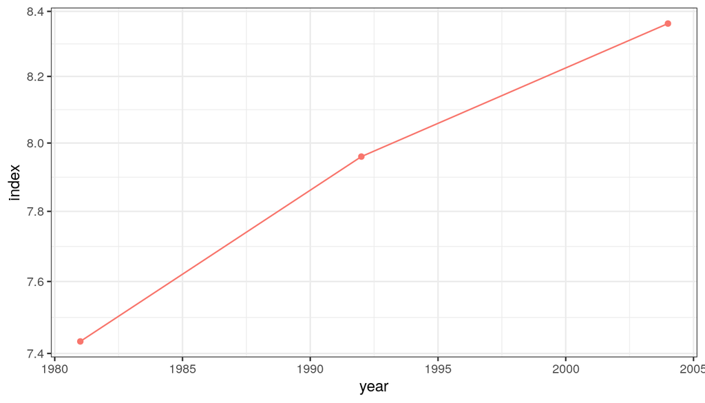

```r
ggplot(data = subset(smDat, species %in% ErrorSp), aes(x=year, y=index)) +
  geom_line(aes(col=species)) +
  geom_point(aes(col=species)) +
  scale_y_log10() +
  theme_bw() +
  theme(legend.position = "none")
```

Clearly these are species with insufficient data to do the smoothing.

## Investigate Warnings

Now let’s look at the species with warnings. Which groups are they in?

```r
warningSp <- unique(subset(mD, status == "warning")$spName)
table(subset(mD, status == "warning")$group)
```

```
##
##            birds       bumblebees      butterflies             fish
##                7                1                4                1
## fw invertebrates          mammals            moths  vascular plants
##                2                7               16                1
```

Is it something to do with incomplete time series?

```r
temp <- subset(mD, status == "warning")$yFill
table(temp==1)
```

```
##
## FALSE  TRUE
##     8    31
```

Most of them are complete.

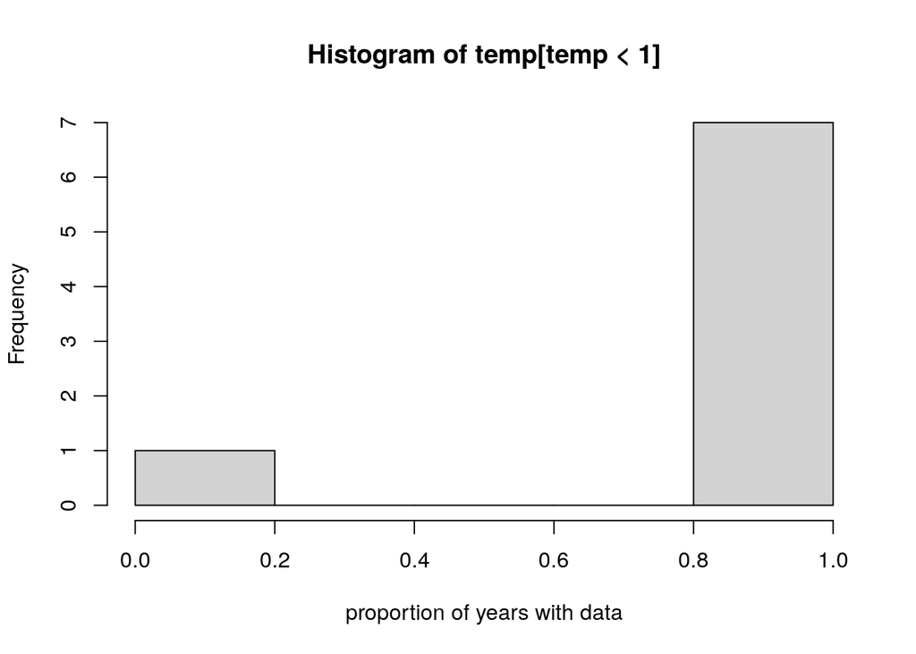

```r
hist(temp[temp<1], xlab="proportion of years with data")
```

# Plot smoothed trends

## Sparse time-series

First, look at the species whose series contain lots of missing values

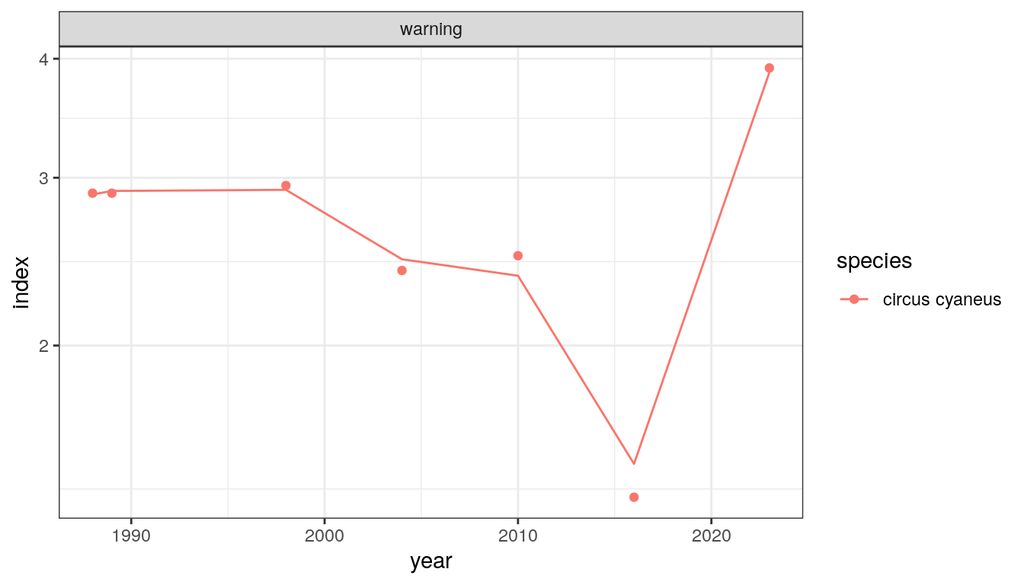

There’s not a whole lot to see here. The smoothed trends look ok, but not really different from the unsmoothed.

```r
subset(mD, spName %in% missingWarnSp, select = c(1,2,3,5,6,8))
```

|  | spName | ySpan | nYObs | df | status | survey |
| --- | --- | --- | --- | --- | --- | --- |
| 40 | circus cyaneus | 36 | 7 | 6 | warning | scar |

In summary, the incomplete time series are all in the SCARRABS data, and there doesn’t seem to be a big issue associated with such data.

## Plants

The plants have a short time-series: only ten years. I thought that smoothing wouldn’t make a lot of sense. In fact, but there are some plants that fluctuate a lot, giving the appearance of big changes from the baseline.

```
## [1] 10
```

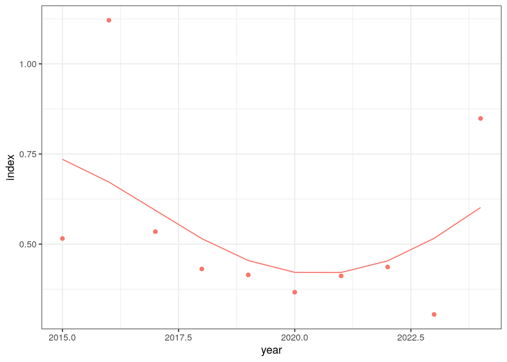

## Mammals

For the mammals, my hunch is that the species with warnings are the bats, since these are a shorter time series than other groups

```r
table(subset(mD, status == "warning" & group =="mammals")$survey)
```

```
##
##  nbmp  ndmp nwvmp
##     5     1     1
```

All are already smoothed. So let’s ignore these.

## Fish

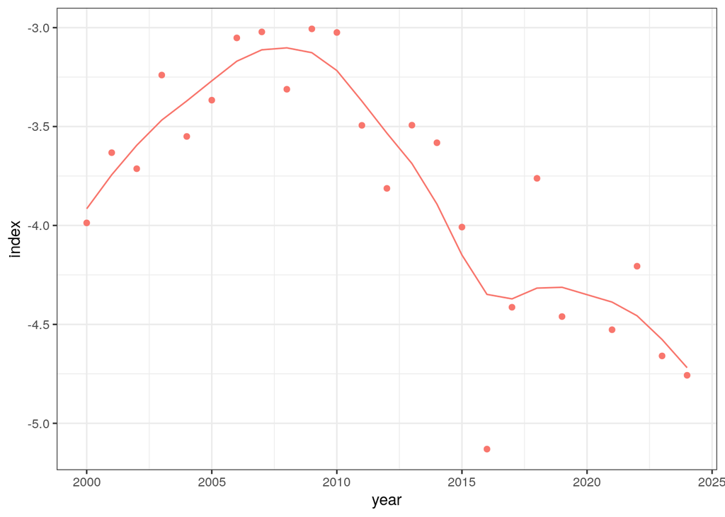

These are the fish with warnings. Some are quite noisy and the smoothing does look like it could be helpful.

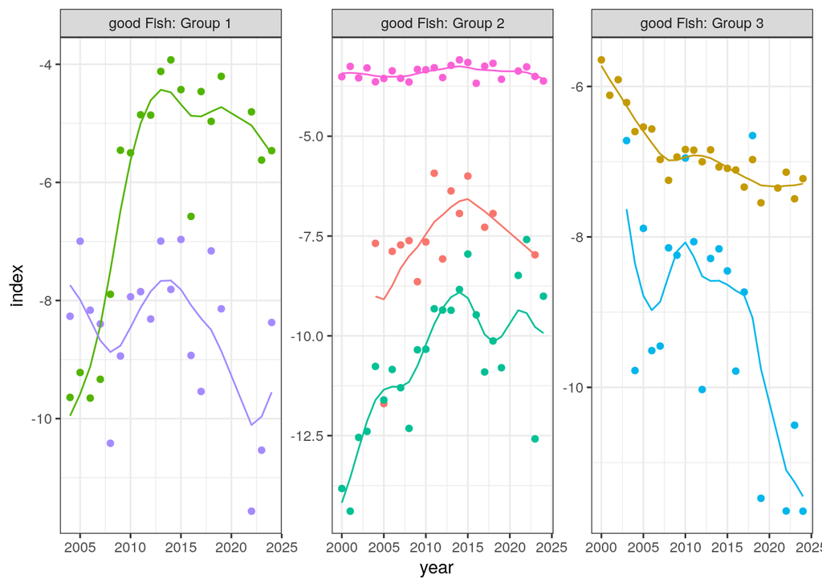

## Freshwater invertebrates

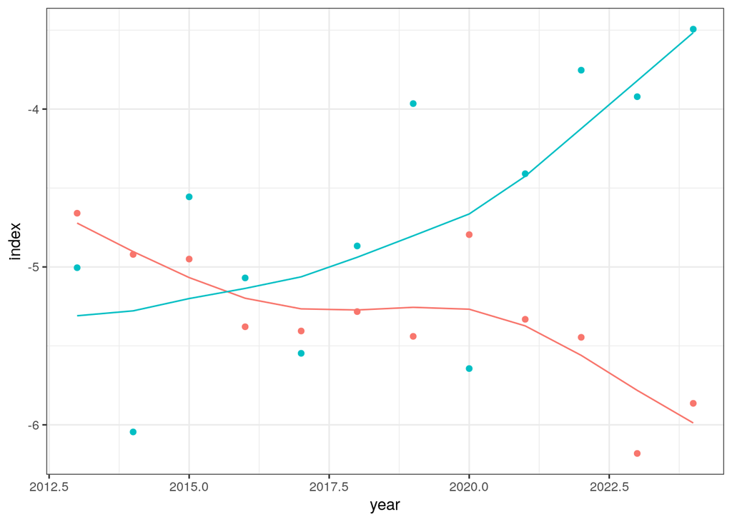

## Butterflies

Now the butterflies with warnings.

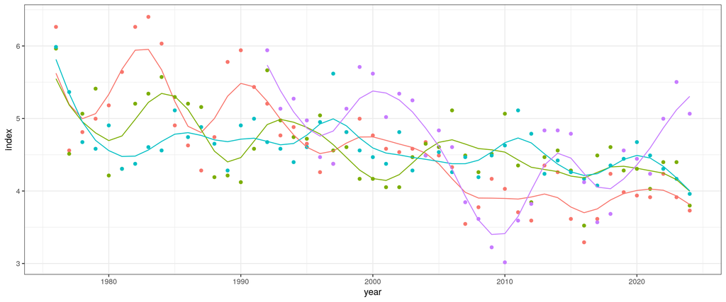

Here is a case where smoothing really does like is will help. All these trends are rather noisy.

Now plot those without warnings:

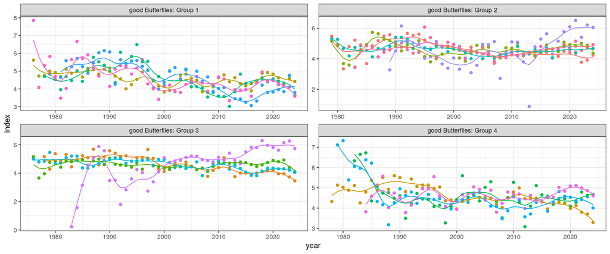

## Moths

For the moths, it would be helpful to understand the difference between the BC Priority species and the more widespread RIS species.

```r
table(subset(mD, status == "warning" & group =="moths")$survey)
```

```
##
## prior_m     ris
##       4      12
```

Let’s plot all the BC priority moths toghether

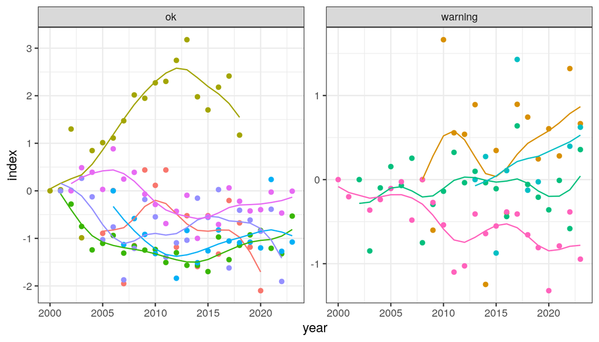

No really obvious difference, although again the variance seems higher on the species with warnings.

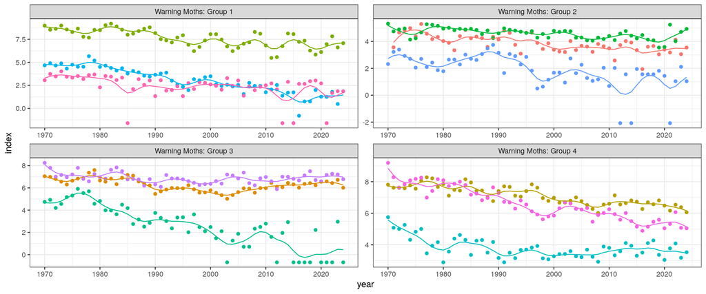

Nothing especially alarming here, except for some noticeable behaviour where zeros have been controlled for.

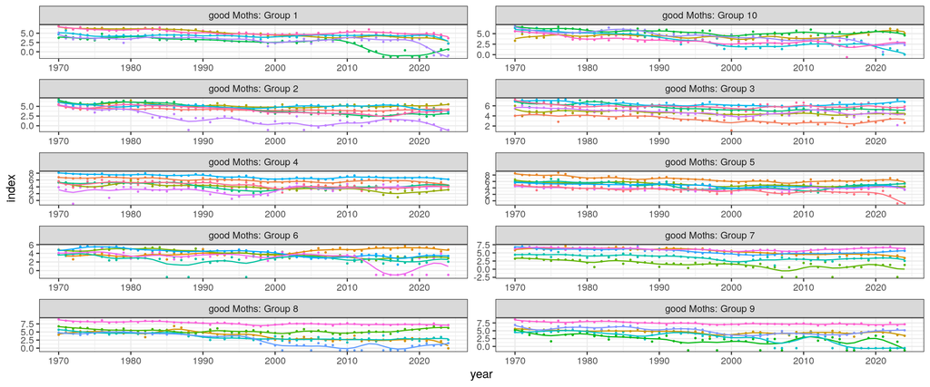

## Birds

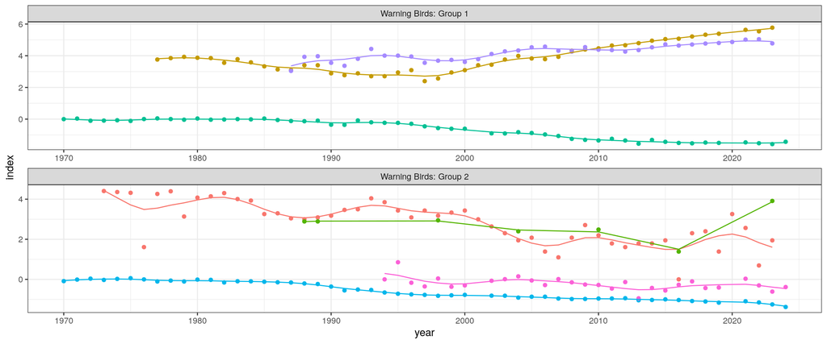

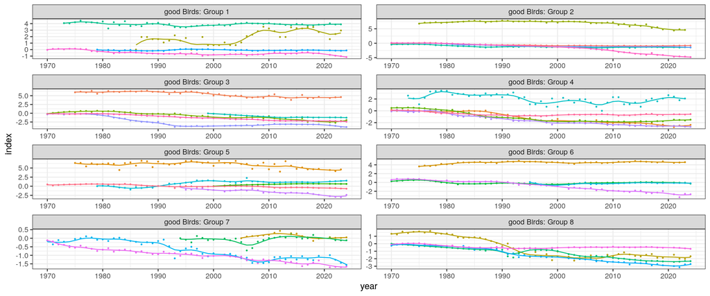

## Conclusion

We have checked the warning messages and are happy to proceed with the smoothed time-series as they don’t appear to be concerning

Potential development option: It would be worth revisiting the pseudozeros again. The value we choose may be having an impact. We could also consider trialling using a different number of degrees of freedom.

# Compare smoothed with unsmoothed trends

Here we use the data that are smoothed on the log scale

```r
temp <- subset(smDat, !is.na(smFitted))
spCorr <- lapply(unique(temp$species), function(sp){
  sub.set <- subset(temp, sp==species)
  P <- with(sub.set, cor.test(smFitted, index)$estimate)
  return(data.frame(species=sp, P=P))
})
spCorr <- dplyr::bind_rows(spCorr)
spCorr <- merge(spCorr, oneRowPerSpecies)

spCorr %>% group_by(survey) %>%
  summarise(
    nSp = length(P),
    q1 = quantile(P, 0.25, na.rm=T),
    q2 = median(P, na.rm=T),
    q3 = quantile(P, 0.75, na.rm = T))
```

| survey | nSp | q1 | q2 | q3 |
| --- | --- | --- | --- | --- |
| bbs_m | 1 | 0.9503767 | 0.9503767 | 0.9503767 |
| beewalks | 1 | 0.7168526 | 0.7168526 | 0.7168526 |
| fish | 8 | 0.7229544 | 0.8096729 | 0.9182056 |
| fw_inv | 2 | 0.7824887 | 0.8115984 | 0.8407081 |
| nbmp | 5 | 0.9846061 | 0.9894610 | 0.9988849 |
| ndmp | 1 | 0.9578021 | 0.9578021 | 0.9578021 |
| npms | 1 | 0.6256390 | 0.6256390 | 0.6256390 |
| nwvmp | 1 | 0.7120686 | 0.7120686 | 0.7120686 |
| prior_m | 10 | 0.5804680 | 0.6844039 | 0.8231483 |
| rbbp | 6 | 0.8655363 | 0.8865666 | 0.9324886 |

[output cut: 6 more lines]

# Prepare a single dataset for export

Let’s just check the input and output dataframes have the same number of observations:

```r
nrow(data) == nrow(smDat)
```

```
## [1] TRUE
```

Check whether there are missing values

```r
summary(smDat)
```

```
##    species               year         smFitted            group
##  Length:7139        Min.   :1970   Min.   :-14.18145   Length:7139
##  Class :character   1st Qu.:1987   1st Qu.:  0.08594   Class :character
##  Mode  :character   Median :2001   Median :  3.88502   Mode  :character
##                     Mean   :1999   Mean   :  2.84853
##                     3rd Qu.:2013   3rd Qu.:  4.90901
##                     Max.   :2024   Max.   :  8.87397
##                                    NA's   :3
##     survey              index              index_sm           expIndex
##  Length:7139        Min.   :-14.39225   Min.   :   0.008   Min.   :   0.000
##  Class :character   1st Qu.:  0.05303   1st Qu.:   0.324   1st Qu.:   1.054
##  Mode  :character   Median :  3.83904   Median :   0.731   Median :  46.481
##                     Mean   :  2.85066   Mean   :  59.780   Mean   : 204.897
##                     3rd Qu.:  4.93452   3rd Qu.:   1.126   3rd Qu.: 139.007
##                     Max.   :  9.20194   Max.   :2148.000   Max.   :9916.351
##                                         NA's   :5268
##     status
##  Length:7139
##  Class :character
##  Mode  :character
##
##
##
##
```

Yes. These will be for the species in the “error” and “fewDF” categories. Let’s fix these.

what we’ll do is rename the old `index` column as `temp` (noting that `index_orig` is a column name in the original dataframe).

```r
outDat        <- smDat
outDat$temp   <- outDat$index
outDat$index2 <- outDat$smFitted

# fix NA: these are the species with few degrees of freedom, or that returned errors
# not the negative values when smoothing on the measurement scale - we fixed those earlier
i <- which(is.na(outDat$index2))
outDat$index2[i] <- outDat$temp[i]
outDat$status[i] <- "unsmoothed"


#############   need to run this code block with and without these lines      ###############
#############   first to save with the smoothed vplants, then the unsmoothed  ###############

# now replace the Plants with the original index, because it's not clear that smoothing helps here
i <- which(outDat$survey == "npms")
outDat$index2[i] <- outDat$temp[i]
outDat$status[i] <- "unsmoothed"

#############  end section to repeat  ######################################################



# now replace the Bats with the original index, because these were already smoothed.
i <- which(outDat$survey == "nbmp")
outDat$index2[i] <- outDat$temp[i]
outDat$status[i] <- "SmoothedAlready"

i <- which(!is.na(smDat$index_sm))
outDat$index2[i] <- log(outDat$index_sm[i])
outDat$status[i] <- "SmoothedAlready"

any(is.na(outDat$index2))
```

```
## [1] FALSE
```

```r
table(outDat$status)
```

```
##
##              ok SmoothedAlready      unsmoothed         warning
##            4142            1871              13            1113
```

Summarise by taxonomic group

```r
dcast(unique(outDat[,c("species", "group", "survey","status")]),
      formula = group + survey ~ status)
```

| group | survey | ok | SmoothedAlready | unsmoothed | warning |
| --- | --- | --- | --- | --- | --- |
| birds | rbbp | 3 | 0 | 0 | 3 |
| birds | scar | 0 | 0 | 1 | 1 |
| birds | up | 0 | 3 | 0 | 0 |
| birds | wbi | 0 | 29 | 0 | 0 |
| birds | wwbi | 0 | 4 | 0 | 0 |
| bumblebees | beewalks | 0 | 0 | 0 | 1 |
| butterflies | ukbms | 17 | 0 | 0 | 4 |
| fish | fish | 7 | 0 | 0 | 1 |
| fw invertebrates | fw_inv | 0 | 0 | 0 | 2 |
| mammals | bbs_m | 0 | 1 | 0 | 0 |

[output cut: 6 more lines]

Having checked the file, we can write it out.

```r
write.csv(outDat[,c("species","year","group","survey", "index2","status")],
          file = file.path(datadir, "d6a_spp_ts_engto24_Smoothed_120326.csv"), row.names = FALSE)
```

once have re-run from code block at 610 replacing the smoothed VP time-series

```r
write.csv(outDat[,c("species","year","group","survey", "index2","status")],
          file = file.path(datadir, "d6a_spp_ts_engto24_Smoothed_unsmVP_120326.csv"), row.names = FALSE)
```

# Summary

We have smoothed the species trends on the log scale. We have checked the warnings and found there is no real problem here. However, we may wish to revisit the number of degrees of freedom.

We have used the smoothed trends except for:

1. Bats and other species for which smoothed trends are available
2. for species with only 2-3 years of data